# Customer Churn Prediction

Customer retention is crucial to any business. Maximize customer lifetime value with continued growth in revenue in the customer base is much cheaper than winning new customers. Therefore, if a business is able to predict when a customer is likely to churn beforehand, it would give the company an opportunity to utilize its sales / marketing / product and customer service to help customers make the ultimate decision to stay with the business.

In this model I will use a Telecom customer churn data to build a model and predict when a customer is likely to churn before their contract is ended.

#### Data

Using the telecom churn data provided by kaggle.

https://www.kaggle.com/becksddf/churn-in-telecoms-dataset/version/1.

#### Ideas and reference

- Notebook Structure https://www.kaggle.com/jfzhang1995/exploratory-study-on-feature-selection-f32c02
- Gallary http://gallery.dataiku.com/projects/DKU_CHURN/dashboards/4A29MtD_forecasting-customers-that-are-likely-to-churn/view/T151Z94
- https://towardsdatascience.com/building-a-logistic-regression-in-python-step-by-step-becd4d56c9c8
- https://machinelearningmastery.com/feature-selection-machine-learning-python/
- Ensemble Machine Learning by Ankit Dixit
- Feature transformations with ensembles of trees http://scikit-learn.org/stable/auto_examples/ensemble/plot_feature_transformation.html#sphx-glr-auto-examples-ensemble-plot-feature-transformation-py
- Multiple Models, Pipelines, and Grid Searches https://www.kdnuggets.com/2018/01/managing-machine-learning-workflows-scikit-learn-pipelines-part-3.html
- Churn Prediction: Machine Learning Starter https://www.kaggle.com/mainakdatageek/churn-prediction-machine-learning-starter
- comprehensive-data-exploration-with-python https://www.kaggle.com/pmarcelino/comprehensive-data-exploration-with-python
- Mastering Machine Learning with Python in Six Steps: A Practical
- Classification Accuracy is Not Enough: More Performance Measures You Can Use https://machinelearningmastery.com/classification-accuracy-is-not-enough-more-performance-measures-you-can-use/
- Selecting good features – Part IV: stability selection, RFE and everything side by side http://blog.datadive.net/selecting-good-features-part-iv-stability-selection-rfe-and-everything-side-by-side/

#### TODO

- Imbalance dataset - SMOTE
- Requirement %pip install ...

# Table of Contents

## 1. EDA

### Data Inspections

```python
# Dataset
tele = pd.read_csv('./data/bigml.csv', na_values=["N/A"])
tele.head(2)
tele.columns = [x.lower().replace(" ", "_") for x in tele.columns]
print(tele.shape)
tele.head()
```

```
(3333, 21)
```

|  | state | account_length | area_code | phone_number | international_plan | voice_mail_plan | number_vmail_messages | total_day_minutes | total_day_calls | total_day_charge | ... | total_eve_calls | total_eve_charge | total_night_minutes | total_night_calls | total_night_charge | total_intl_minutes | total_intl_calls | total_intl_charge | customer_service_calls | churn |
| --- | --- | --- | --- | --- | --- | --- | --- | --- | --- | --- | --- | --- | --- | --- | --- | --- | --- | --- | --- | --- | --- |
| 0 | KS | 128 | 415 | 382-4657 | no | yes | 25 | 265.1 | 110 | 45.07 | ... | 99 | 16.78 | 244.7 | 91 | 11.01 | 10.0 | 3 | 2.70 | 1 | False |
| 1 | OH | 107 | 415 | 371-7191 | no | yes | 26 | 161.6 | 123 | 27.47 | ... | 103 | 16.62 | 254.4 | 103 | 11.45 | 13.7 | 3 | 3.70 | 1 | False |
| 2 | NJ | 137 | 415 | 358-1921 | no | no | 0 | 243.4 | 114 | 41.38 | ... | 110 | 10.30 | 162.6 | 104 | 7.32 | 12.2 | 5 | 3.29 | 0 | False |
| 3 | OH | 84 | 408 | 375-9999 | yes | no | 0 | 299.4 | 71 | 50.90 | ... | 88 | 5.26 | 196.9 | 89 | 8.86 | 6.6 | 7 | 1.78 | 2 | False |
| 4 | OK | 75 | 415 | 330-6626 | yes | no | 0 | 166.7 | 113 | 28.34 | ... | 122 | 12.61 | 186.9 | 121 | 8.41 | 10.1 | 3 | 2.73 | 3 | False |

5 rows × 21 columns

```python
tele.dtypes
```

```
state                      object
account_length              int64
area_code                   int64
phone_number               object
international_plan         object
voice_mail_plan            object
number_vmail_messages       int64
total_day_minutes         float64
total_day_calls             int64
total_day_charge          float64
total_eve_minutes         float64
total_eve_calls             int64
total_eve_charge          float64
total_night_minutes       float64
total_night_calls           int64
total_night_charge        float64
total_intl_minutes        float64
total_intl_calls            int64
total_intl_charge         float64
customer_service_calls      int64
churn                        bool
dtype: object
```

```python
print("The features are:")
print("-"*85)
[print(x) for x in tele.columns[:-1]]
print("-"*85)
print('The target is:{}'.format(tele.iloc[:,-1].name))
```

```
The features are:
-------------------------------------------------------------------------------------
state
account_length
area_code
phone_number
international_plan
voice_mail_plan
number_vmail_messages
total_day_minutes
total_day_calls
total_day_charge
total_eve_minutes
total_eve_calls
total_eve_charge
total_night_minutes
total_night_calls
total_night_charge
total_intl_minutes
total_intl_calls
total_intl_charge
customer_service_calls
-------------------------------------------------------------------------------------
The target is:churn
```

### Data transformation

```python
# Turn yes/no or true/false to 1/0
tele['international_plan'] = tele['international_plan'].apply(boolean_conv)
tele['voice_mail_plan'] = tele['voice_mail_plan'].apply(boolean_conv)
tele['churn']= tele['churn']*1
```

```python
numeric_col = list(tele.loc[:, tele.dtypes == 'float64'].columns)
numeric_col = numeric_col + ['account_length', 'number_vmail_messages', 'total_day_calls',
                             'total_eve_calls', 'total_night_calls', 'total_intl_calls',
                             'customer_service_calls']

cat_col = ['international_plan', 'voice_mail_plan']

# Features selection - delete any item that will not affect the predicition.
tele.drop(['state', 'phone_number', 'area_code'], axis=1, inplace=True)

# Id any columns that has null value
tele.isnull().any()
```

```
account_length            False
international_plan        False
voice_mail_plan           False
number_vmail_messages     False
total_day_minutes         False
total_day_calls           False
total_day_charge          False
total_eve_minutes         False
total_eve_calls           False
total_eve_charge          False
total_night_minutes       False
total_night_calls         False
total_night_charge        False
total_intl_minutes        False
total_intl_calls          False
total_intl_charge         False
customer_service_calls    False
churn                     False
dtype: bool
```

#### Using statemodels.api to quickly inspect the dataset and possibly using the p value to assist with features selection

```python
lr=sm.Logit(tele.churn,tele.iloc[:,0:-1])
result=lr.fit()
print("A SM summary of the data")
print(result.summary())
```

```
Optimization terminated successfully.
         Current function value: 0.347868
         Iterations 7
A SM summary of the data
                           Logit Regression Results
==============================================================================
Dep. Variable:                  churn   No. Observations:                 3333
Model:                          Logit   Df Residuals:                     3316
Method:                           MLE   Df Model:                           16
Date:                Fri, 23 Mar 2018   Pseudo R-squ.:                  0.1593
Time:                        20:56:25   Log-Likelihood:                -1159.4
converged:                       True   LL-Null:                       -1379.1
                                        LLR p-value:                 1.945e-83
==========================================================================================
                             coef    std err          z      P>|z|      [0.025      0.975]
------------------------------------------------------------------------------------------
account_length            -0.0025      0.001     -1.907      0.057      -0.005    7.02e-05
international_plan         1.9624      0.141     13.884      0.000       1.685       2.239
voice_mail_plan           -1.8596      0.545     -3.411      0.001      -2.928      -0.791
number_vmail_messages      0.0312      0.017      1.815      0.069      -0.002       0.065
total_day_minutes          0.4584      3.150      0.146      0.884      -5.716       6.633
total_day_calls           -0.0106      0.002     -4.384      0.000      -0.015      -0.006
total_day_charge          -2.6440     18.532     -0.143      0.887     -38.967      33.679
total_eve_minutes          1.0258      1.573      0.652      0.514      -2.056       4.108
total_eve_calls           -0.0125      0.002     -5.041      0.000      -0.017      -0.008
total_eve_charge         -12.0487     18.500     -0.651      0.515     -48.308      24.210
total_night_minutes       -0.2006      0.839     -0.239      0.811      -1.846       1.445
total_night_calls         -0.0136      0.003     -5.401      0.000      -0.019      -0.009
total_night_charge         4.4330     18.653      0.238      0.812     -32.127      40.993
total_intl_minutes        -3.9943      5.108     -0.782      0.434     -14.005       6.017
total_intl_calls          -0.1261      0.025     -5.121      0.000      -0.174      -0.078
total_intl_charge         14.8103     18.917      0.783      0.434     -22.266      51.887
customer_service_calls     0.4216      0.037     11.421      0.000       0.349       0.494
==========================================================================================
```

```python
print( "The p value ranks - the feature significance to the model:\n")
top_features=result.pvalues.sort_values(ascending=True).map(lambda x: '%.5f' % x).index[0:16].tolist()
print(result.pvalues.sort_values(ascending=True).map(lambda x: '%.5f' % x))
```

```
The p value ranks - the feature significance to the model:

international_plan        0.00000
customer_service_calls    0.00000
total_night_calls         0.00000
total_intl_calls          0.00000
total_eve_calls           0.00000
total_day_calls           0.00001
voice_mail_plan           0.00065
account_length            0.05656
number_vmail_messages     0.06945
total_intl_charge         0.43368
total_intl_minutes        0.43420
total_eve_minutes         0.51420
total_eve_charge          0.51486
total_night_minutes       0.81113
total_night_charge        0.81215
total_day_minutes         0.88430
total_day_charge          0.88655
dtype: object
```

##### Learning: SM

This is just a guideline to help me get a quick understanding of the dataset. The statistical significance rank above will not be used as the basis for my feature selection later, in order for me to build the best prediction model.

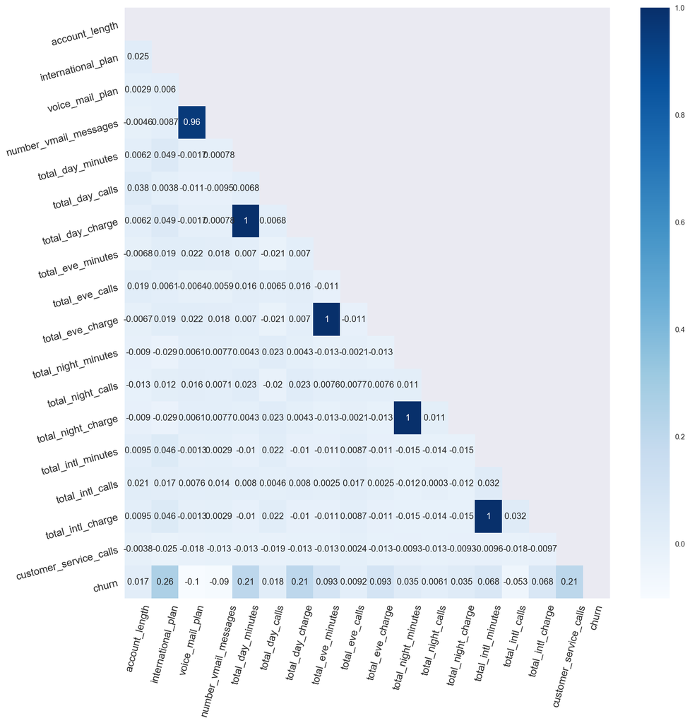

```python
correlation_heat_map(tele)
```

```python
tele.corr()[(tele.corr() >0.9) & (tele.corr() <1) ]
```

|  | account_length | international_plan | voice_mail_plan | number_vmail_messages | total_day_minutes | total_day_calls | total_day_charge | total_eve_minutes | total_eve_calls | total_eve_charge | total_night_minutes | total_night_calls | total_night_charge | total_intl_minutes | total_intl_calls | total_intl_charge | customer_service_calls | churn |
| --- | --- | --- | --- | --- | --- | --- | --- | --- | --- | --- | --- | --- | --- | --- | --- | --- | --- | --- |
| account_length | NaN | NaN | NaN | NaN | NaN | NaN | NaN | NaN | NaN | NaN | NaN | NaN | NaN | NaN | NaN | NaN | NaN | NaN |
| international_plan | NaN | NaN | NaN | NaN | NaN | NaN | NaN | NaN | NaN | NaN | NaN | NaN | NaN | NaN | NaN | NaN | NaN | NaN |
| voice_mail_plan | NaN | NaN | NaN | 0.956927 | NaN | NaN | NaN | NaN | NaN | NaN | NaN | NaN | NaN | NaN | NaN | NaN | NaN | NaN |
| number_vmail_messages | NaN | NaN | 0.956927 | NaN | NaN | NaN | NaN | NaN | NaN | NaN | NaN | NaN | NaN | NaN | NaN | NaN | NaN | NaN |
| total_day_minutes | NaN | NaN | NaN | NaN | NaN | NaN | 1.0 | NaN | NaN | NaN | NaN | NaN | NaN | NaN | NaN | NaN | NaN | NaN |
| total_day_calls | NaN | NaN | NaN | NaN | NaN | NaN | NaN | NaN | NaN | NaN | NaN | NaN | NaN | NaN | NaN | NaN | NaN | NaN |
| total_day_charge | NaN | NaN | NaN | NaN | 1.0 | NaN | NaN | NaN | NaN | NaN | NaN | NaN | NaN | NaN | NaN | NaN | NaN | NaN |
| total_eve_minutes | NaN | NaN | NaN | NaN | NaN | NaN | NaN | NaN | NaN | 1.0 | NaN | NaN | NaN | NaN | NaN | NaN | NaN | NaN |
| total_eve_calls | NaN | NaN | NaN | NaN | NaN | NaN | NaN | NaN | NaN | NaN | NaN | NaN | NaN | NaN | NaN | NaN | NaN | NaN |
| total_eve_charge | NaN | NaN | NaN | NaN | NaN | NaN | NaN | 1.0 | NaN | NaN | NaN | NaN | NaN | NaN | NaN | NaN | NaN | NaN |
| total_night_minutes | NaN | NaN | NaN | NaN | NaN | NaN | NaN | NaN | NaN | NaN | NaN | NaN | 0.999999 | NaN | NaN | NaN | NaN | NaN |
| total_night_calls | NaN | NaN | NaN | NaN | NaN | NaN | NaN | NaN | NaN | NaN | NaN | NaN | NaN | NaN | NaN | NaN | NaN | NaN |
| total_night_charge | NaN | NaN | NaN | NaN | NaN | NaN | NaN | NaN | NaN | NaN | 0.999999 | NaN | NaN | NaN | NaN | NaN | NaN | NaN |
| total_intl_minutes | NaN | NaN | NaN | NaN | NaN | NaN | NaN | NaN | NaN | NaN | NaN | NaN | NaN | NaN | NaN | 0.999993 | NaN | NaN |
| total_intl_calls | NaN | NaN | NaN | NaN | NaN | NaN | NaN | NaN | NaN | NaN | NaN | NaN | NaN | NaN | NaN | NaN | NaN | NaN |
| total_intl_charge | NaN | NaN | NaN | NaN | NaN | NaN | NaN | NaN | NaN | NaN | NaN | NaN | NaN | 0.999993 | NaN | NaN | NaN | NaN |
| customer_service_calls | NaN | NaN | NaN | NaN | NaN | NaN | NaN | NaN | NaN | NaN | NaN | NaN | NaN | NaN | NaN | NaN | NaN | NaN |
| churn | NaN | NaN | NaN | NaN | NaN | NaN | NaN | NaN | NaN | NaN | NaN | NaN | NaN | NaN | NaN | NaN | NaN | NaN |

###### Learning: Multicollinearity

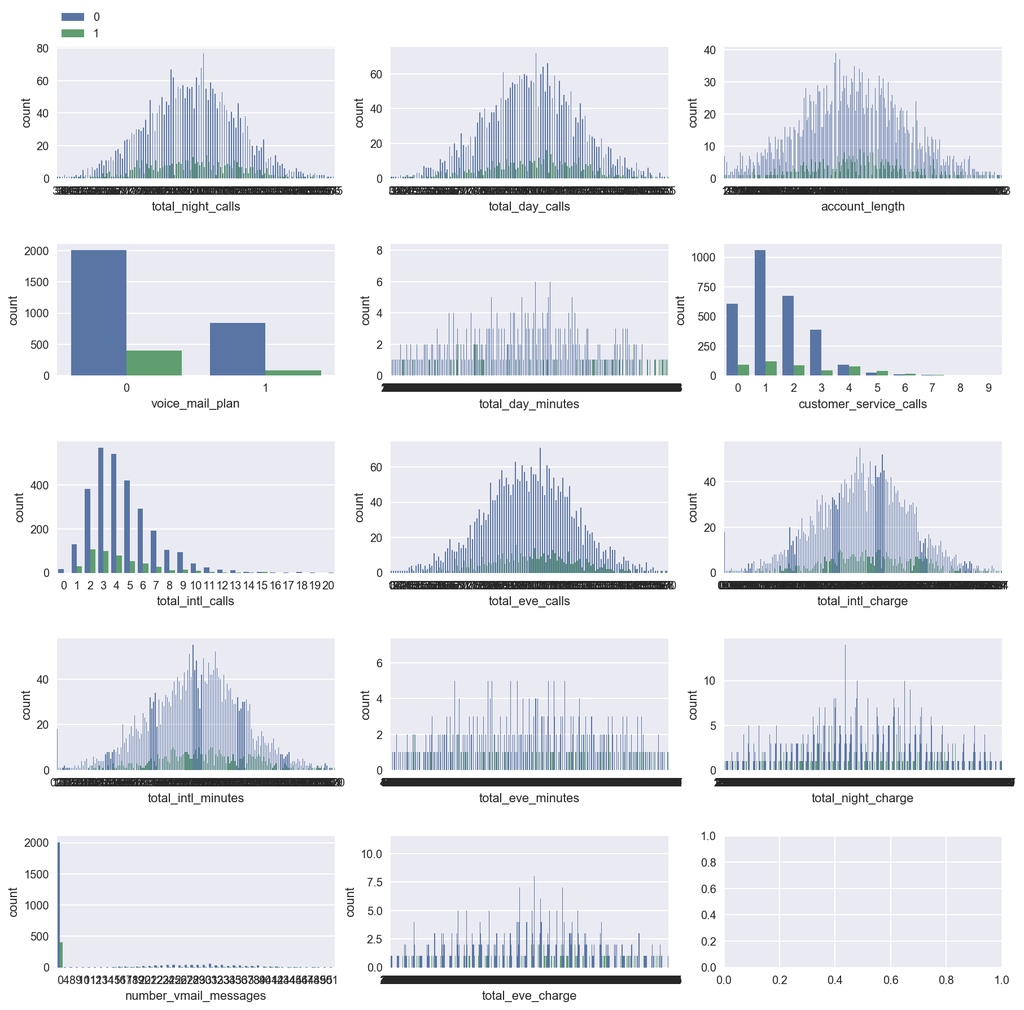

```python
col_2 = col = list(set(top_features) -set(['international_plan']))
tele_temp= tele[col_2]
fig,ax =plt.subplots(5,3,figsize=(15,15))
fig.subplots_adjust(hspace=.5)
for i in range(0,14):
    g = sns.countplot(x=tele_temp.iloc[:,i], hue=tele["churn"], ax=ax[divmod(i,3)])
    g.legend(bbox_to_anchor=(0., 1.02, 1., .102), loc=3, mode="expand", borderaxespad=0.) if i==0 else g.legend_.remove()
#for tick in ax[3,3].get_xticklabels():
 #   tick.set_rotation(45)
```

```
Numerical features distribution
```

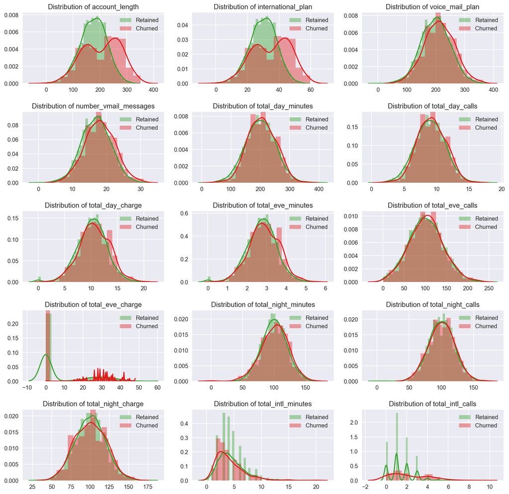

```python
# Final
tele_n =tele[numeric_col]
tele_n['churn']= tele['churn']*1
tele_n_col = tele_n.columns.tolist()
t_T = tele_n[tele_n['churn']==1]

t_F = tele_n[tele_n['churn']==0]

print("Numerical features distribution")
fig,axs =plt.subplots(5,3,figsize=(15,15))
fig.subplots_adjust(hspace=.4)
for i, value in enumerate(tele_n_col[0:-1]):
   # print (i,value)
    sns.distplot(t_F.loc[:,[value]], ax=axs[divmod(i,3)], color=sns.color_palette(palette)[3])
    g=sns.distplot(t_T.loc[:,[value]], ax=axs[divmod(i,3)],color=sns.color_palette(palette)[5])
    axs[divmod(i,3)].set_title('Distribution of {}'.format(tele.columns[i]))
    axs[divmod(i,3)].legend(['Retained', 'Churned'])
    #g = sns.countplot(x=tele_temp.iloc[:,i], hue=tele["churn"], ax=ax[divmod(i,3)])
    #g.legend(bbox_to_anchor=(0., 1.02, 1., .102), loc=3, mode="expand", borderaxespad=0.) if i==0 else g.legend_.remove()
```

###### Learning: Distribution

Apart from customer_service_calls,number_vmail_messages,total_intl_calls all the other features look like a normal distribution. Lets have a look at the boxplot and investigate the reason for the skewed features. In addition, we will take a closer look at the account length and try to identify if there is any patterns between churned and retained customers.

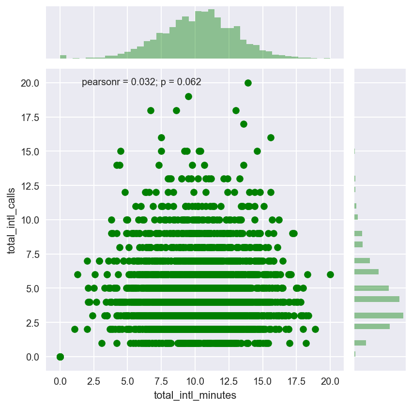

```python
sns.jointplot(data=tele, x='total_intl_minutes', y='total_intl_calls', color='g')
```

### Boxplot

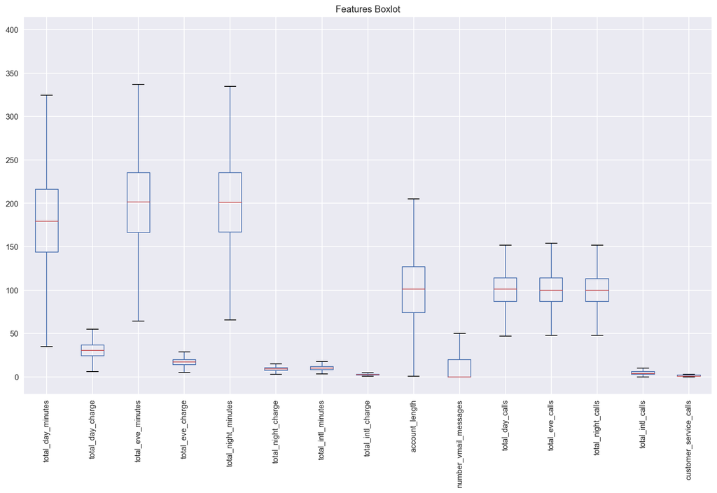

```python
tele_n.boxplot(figsize=(16, 9) )
plt.xticks(rotation=90)
plt.title("Features Boxlot")
plt.show()
```

## 2. Modeling

### Initial model

```python
# basedline
print(tele.groupby('churn').size())
print("The baseline is {:.3f}".format( np.mean(tele['churn']) *100))
#print ("This indicated an imbalanced dataset")
```

```
churn
0    2850
1     483
dtype: int64
The baseline is 14.491
```

##### Learning: Baseline

This indicates the dataset is imbalanced. For some models, this won't be an issue but for others it will be. If we have not addressed this in the modelings below, the prediction results could be misleading.

A few techniques have been commonly used(https://elitedatascience.com/imbalanced-classes):

- Up-sample Minority Class
- Down-sample Majority Class
- Change Your Performance Metric
- Penalize Algorithms (Cost-Sensitive Training)
- Use Tree-Based Algorithms

In this notebook a mixture of techniques have been used. For any classifer that provides a class_weight parameter it will be used.

```python
lr = LogisticRegression(class_weight='balanced')
# using a 25-fold cross-val for fun
scores = cross_val_score(lr, X, y, cv=25)
print(scores)
print(np.mean(scores))
a=np.mean(scores)
```

```
[ 0.71641791  0.67164179  0.7238806   0.79104478  0.79104478  0.74626866
  0.79850746  0.76119403  0.76691729  0.72932331  0.78947368  0.7518797
  0.78195489  0.77443609  0.81203008  0.79699248  0.7518797   0.73684211
  0.79699248  0.76691729  0.79699248  0.7518797   0.77443609  0.80451128
  0.76691729]
0.766015037594
```

```python
scores = cross_val_score(lr, scaled_tele_c, y, cv=25)
print(scores)
print(np.mean(scores))
b =np.mean(scores)
print("The accuracy improved by {:.3} when using the standardised data".format(b-a))
```

```
[ 0.70149254  0.65671642  0.7238806   0.78358209  0.79104478  0.75373134
  0.79850746  0.76865672  0.76691729  0.73684211  0.80451128  0.7593985
  0.78947368  0.80451128  0.82706767  0.78947368  0.7518797   0.73684211
  0.77443609  0.77443609  0.78947368  0.76691729  0.78195489  0.80451128
  0.77443609]
0.768427785883
The accuracy improved by 0.00241 when using the standardised data
```

##### Learning: Imbalanced dataset

As we can see from the result, the prediction accuracy is higher when I haven't changed the weighting, which could be misleading. The model will ignore the minority class in favor of the majority class.

```python
# Construct the confusion matrix.
conmat = np.array(confusion_matrix(y_test, yhat, labels=[1, 0]))

confusion = pd.DataFrame(
    conmat,
    index=['churned', 'Retained'],
    columns=['predicted_churn', 'predicted_retained'])
confusion
```

|  | predicted_churn | predicted_retained |
| --- | --- | --- |
| churned | 98 | 27 |
| Retained | 157 | 552 |

### Plot an ROC curve using your predicted probabilities on the test data.

Create a dataframe of the predicted probabilities that each observation belongs to the relevant class

```python
# generate evaluation metrics
print ("Accuracy :", metrics.accuracy_score(y_test, lr.predict(X_test)))
print ("AUC :", metrics.roc_auc_score(y_test, lr.predict_proba(X_test)[:,1]))

print ("Confusion matrix :",metrics.confusion_matrix(y, lr.predict(X)))
print ("classification report :\n", metrics.classification_report(y_test, lr.predict(X_test)))
```

```
Accuracy : 0.779376498801
AUC : 0.838578279267
Confusion matrix : [[   0 2850]
 [   0  483]]
classification report :
              precision    recall  f1-score   support

          0       0.95      0.78      0.86       709
          1       0.38      0.78      0.52       125

avg / total       0.87      0.78      0.81       834
```

### Predict with the imbalanced dataset

```python
lr_imbalanced = LogisticRegression()
# using a 25-fold cross-val for fun
scores_umbalanced = cross_val_score(lr_imbalanced, X, y, cv=25)
print(scores_umbalanced)
print(np.mean(scores_umbalanced))
a=np.mean(scores_umbalanced)
```

```
[ 0.84328358  0.8358209   0.85820896  0.89552239  0.87313433  0.86567164
  0.84328358  0.85074627  0.85714286  0.84962406  0.85714286  0.84210526
  0.84962406  0.86466165  0.86466165  0.87969925  0.87218045  0.84962406
  0.86466165  0.87969925  0.86466165  0.86466165  0.84210526  0.84962406
  0.86466165]
0.859288519807
```

```python
# generate evaluation metrics on imbalanced data
print ("Accuracy :", metrics.accuracy_score(y_test, lr_imbalanced.predict(X_test)))
print ("AUC :", metrics.roc_auc_score(y_test, lr_imbalanced.predict_proba(X_test)[:,1]))

print ("Confusion matrix :",metrics.confusion_matrix(y, lr_imbalanced.predict(X)))
print ("classification report :\n", metrics.classification_report(y_test, lr_imbalanced.predict(X_test)))
```

```
Accuracy : 0.859712230216
AUC : 0.835125528914
Confusion matrix : [[   0 2850]
 [   0  483]]
classification report :
              precision    recall  f1-score   support

          0       0.87      0.98      0.92       709
          1       0.60      0.20      0.30       125

avg / total       0.83      0.86      0.83       834
```

#### learning: Imbalanced data prediction

From the result above, when the model uses the imbalanced dataset, the result are inflated. There is a danger the company could make the wrong business decision based on this model.

### Plotting the ROC curve, calculating AUC

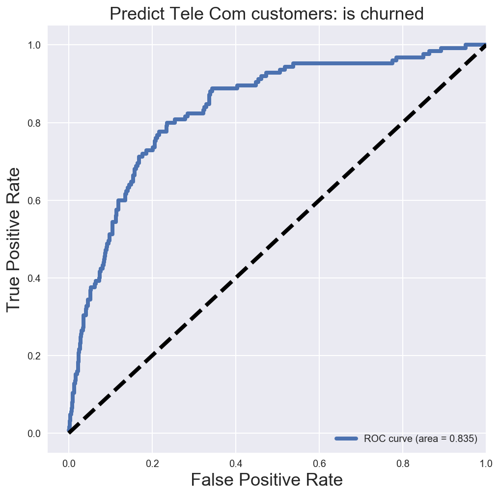

```python
fpr, tpr, _ = roc_curve(y_test, yhat_pp[:, 1])
roc_auc = auc(fpr, tpr)

plt.figure(figsize=[8, 8])
plt.plot(fpr, tpr, label='ROC curve (area = %0.3f)' % roc_auc, linewidth=4)
plt.plot([0, 1], [0, 1], 'k--', linewidth=4)
plt.xlim([-0.05, 1.0])
plt.ylim([-0.05, 1.05])
plt.xlabel('False Positive Rate', fontsize=18)
plt.ylabel('True Positive Rate', fontsize=18)
plt.title('Predict Tele Com customers: is churned', fontsize=18)
plt.legend(loc="lower right")
plt.show()
```

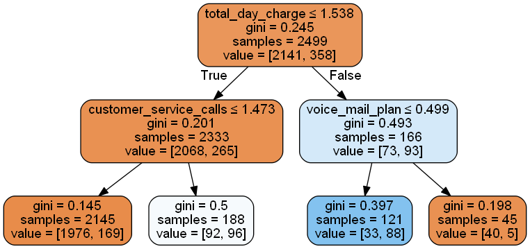

```python
# Build a decision tree
model = DecisionTreeClassifier(max_depth=2)
# Fits the model
model.fit(X_train, y_train)

# initialize the output file object
dot_data = StringIO()
# the DecisionTreeClassifier object here is model
# feature_names  put the columns of the matrix X
# other options are for file output and plotting

graph = build_tree_image(model,dot_data,X_train)
Image(graph.create_png())
```

```python
# Check: Are you able to evaluate the decision tree model using cross-validation methods?
# In your groups from earlier, work on evaluating the decision tree using cross-validation methods.
# What metrics would work best? Why?

for scoring in ['roc_auc', 'accuracy', 'recall', 'precision']:
    scores = cross_val_score(model, X_test, y_test, scoring=scoring, cv=5)
    print(scoring, ':')
    print('CV {} {}, Average {} {}'.format(scoring, scores, scoring,
                                           scores.mean()))
```

```
roc_auc :
CV roc_auc [ 0.72732394  0.74549296  0.73323944  0.63295775  0.77460993], Average roc_auc 0.7227248027170112
accuracy :
CV accuracy [ 0.86826347  0.85628743  0.8742515   0.8742515   0.86144578], Average accuracy 0.8668999350696197
recall :
CV recall [ 0.52  0.16  0.24  0.2   0.24], Average recall 0.272
precision :
CV precision [ 0.56521739  0.57142857  0.75        0.83333333  0.6       ], Average precision 0.6639958592132505
```

#### Learning: Adjusting Decision Trees to Avoid Overfitting

You can control for overfitting in decision trees by adjusting one of the following parameters:

max_depth: Control the maximum number of questions. min_samples_in_leaf: Control the minimum number of records in each node. Test each of these parameters below.

#### V2 Build bench mark and compare the score of each models

```python
LR = LogisticRegression(random_state=42,class_weight='balanced')
RF = RandomForestClassifier(n_estimators = 100, random_state=42,class_weight='balanced')
SVM = SVC(random_state=42, probability=True,class_weight='balanced')
KNC = KNeighborsClassifier()
DTC = DecisionTreeClassifier(class_weight='balanced')
ABC = AdaBoostClassifier(n_estimators = 100)
BC = BaggingClassifier(n_estimators = 100)
GBC = GradientBoostingClassifier(n_estimators = 100)

X_train, X_test, y_train, y_test = train_test_split(scaled_tele_c, y, test_size=0.25, random_state=42)

clfs = []
print('10-fold cross validation:')
print('-'*85)
for clf, label in zip([LR, RF, SVM, KNC, DTC, ABC, BC, GBC],
                      ['Logistic Regression',
                       'Random Forest',
                       'Support Vector Machine',
                       'KNeighbors',
                       'Decision Tree',
                       'Ada Boost',
                       'Bagging',
                       'Gradient Boosting']):

    for scoring in ['roc_auc', 'accuracy', 'recall', 'precision']:
        scores = cross_val_score(clf, X_train, y_train, scoring=scoring, cv=10)
        print(scoring.upper(), ':')
        print('{}: Train CV average {} is {:0.2f}, '.format(label.upper(), scoring,scores.mean()))
        md = clf.fit(X_train, y_train)
        clfs.append(md)
        print("Test Accuracy: %0.2f " % (metrics.accuracy_score(clf.predict(X_test), y_test)))
        print('-'*85)
```

```
10-fold cross validation:
-------------------------------------------------------------------------------------
ROC_AUC :
LOGISTIC REGRESSION: Train CV average roc_auc is 0.81,
Test Accuracy: 0.78
-------------------------------------------------------------------------------------
ACCURACY :
LOGISTIC REGRESSION: Train CV average accuracy is 0.77,
Test Accuracy: 0.78
-------------------------------------------------------------------------------------
RECALL :
LOGISTIC REGRESSION: Train CV average recall is 0.72,
Test Accuracy: 0.78
-------------------------------------------------------------------------------------
PRECISION :
LOGISTIC REGRESSION: Train CV average precision is 0.35,
Test Accuracy: 0.78
-------------------------------------------------------------------------------------
ROC_AUC :
RANDOM FOREST: Train CV average roc_auc is 0.90,
Test Accuracy: 0.95
-------------------------------------------------------------------------------------
ACCURACY :
RANDOM FOREST: Train CV average accuracy is 0.95,
Test Accuracy: 0.95
-------------------------------------------------------------------------------------
RECALL :
RANDOM FOREST: Train CV average recall is 0.67,
Test Accuracy: 0.95
-------------------------------------------------------------------------------------
PRECISION :
RANDOM FOREST: Train CV average precision is 0.95,
Test Accuracy: 0.95
-------------------------------------------------------------------------------------
ROC_AUC :
SUPPORT VECTOR MACHINE: Train CV average roc_auc is 0.90,
Test Accuracy: 0.91
-------------------------------------------------------------------------------------
ACCURACY :
SUPPORT VECTOR MACHINE: Train CV average accuracy is 0.90,
```

[output cut: 75 more lines]

```
GRADIENT BOOSTING: Train CV average roc_auc is 0.91,
Test Accuracy: 0.94
-------------------------------------------------------------------------------------
ACCURACY :
GRADIENT BOOSTING: Train CV average accuracy is 0.95,
Test Accuracy: 0.94
-------------------------------------------------------------------------------------
RECALL :
GRADIENT BOOSTING: Train CV average recall is 0.73,
Test Accuracy: 0.94
-------------------------------------------------------------------------------------
PRECISION :
GRADIENT BOOSTING: Train CV average precision is 0.93,
Test Accuracy: 0.94
-------------------------------------------------------------------------------------
```

#### Learning: 10-fold cross validation

From the result, RANDOM FOREST/BAGGING gave the highest accuracy of 0.95.

*"Bootstrap aggregating, also called bagging, is a machine learning ensemble meta-algorithm designed to improve the stability and accuracy of machine learning algorithms used in statistical classification and regression. It also reduces variance and helps to avoid overfitting. Although it is usually applied to decision tree methods, it can be used with any type of method. Bagging is a special case of the model averaging approach. - Wikipedia"*

### Plot Feature Transformation

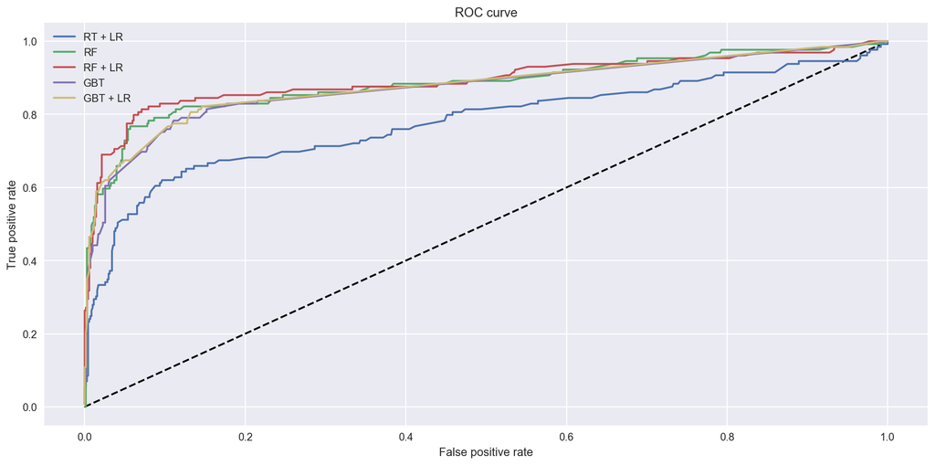

```python
# Author: Tim Head <betatim@gmail.com>
# http://scikit-learn.org/stable/auto_examples/ensemble/plot_feature_transformation.html
# #sphx-glr-auto-examples-ensemble-plot-feature-transformation-py
# License: BSD 3 clause

n_estimator = 10
#X, y = short_X, y
X_train, X_test, y_train, y_test = train_test_split(X, y, test_size=0.25)
# It is important to train the ensemble of trees on a different subset
# of the training data than the linear regression model to avoid
# overfitting, in particular if the total number of leaves is
# similar to the number of training samples
X_train, X_train_lr, y_train, y_train_lr = train_test_split(X_train,
                                                            y_train,
                                                            test_size=0.25)


# Unsupervised transformation based on totally random trees
rt = RandomTreesEmbedding(max_depth=3, n_estimators=n_estimator,
    random_state=42)

rt_lm = LogisticRegression()
pipeline = make_pipeline(rt, rt_lm)
pipeline.fit(X_train, y_train)
y_pred_rt = pipeline.predict_proba(X_test)[:, 1]
fpr_rt_lm, tpr_rt_lm, _ = roc_curve(y_test, y_pred_rt)

# Supervised transformation based on random forests
rf = RandomForestClassifier(max_depth=3, n_estimators=n_estimator)
rf_enc = OneHotEncoder()
rf_lm = LogisticRegression()
rf.fit(X_train, y_train)
rf_enc.fit(rf.apply(X_train))
rf_lm.fit(rf_enc.transform(rf.apply(X_train_lr)), y_train_lr)

y_pred_rf_lm = rf_lm.predict_proba(rf_enc.transform(rf.apply(X_test)))[:, 1]
fpr_rf_lm, tpr_rf_lm, _ = roc_curve(y_test, y_pred_rf_lm)

grd = GradientBoostingClassifier(n_estimators=n_estimator)
grd_enc = OneHotEncoder()
grd_lm = LogisticRegression()
grd.fit(X_train, y_train)
grd_enc.fit(grd.apply(X_train)[:, :, 0])
grd_lm.fit(grd_enc.transform(grd.apply(X_train_lr)[:, :, 0]), y_train_lr)

y_pred_grd_lm = grd_lm.predict_proba(
    grd_enc.transform(grd.apply(X_test)[:, :, 0]))[:, 1]
fpr_grd_lm, tpr_grd_lm, _ = roc_curve(y_test, y_pred_grd_lm)


# The gradient boosted model by itself
y_pred_grd = grd.predict_proba(X_test)[:, 1]
fpr_grd, tpr_grd, _ = roc_curve(y_test, y_pred_grd)


# The random forest model by itself
y_pred_rf = rf.predict_proba(X_test)[:, 1]
fpr_rf, tpr_rf, _ = roc_curve(y_test, y_pred_rf)

plt.figure(1)
plt.plot([0, 1], [0, 1], 'k--')
plt.plot(fpr_rt_lm, tpr_rt_lm, label='RT + LR')
plt.plot(fpr_rf, tpr_rf, label='RF')
plt.plot(fpr_rf_lm, tpr_rf_lm, label='RF + LR')
plt.plot(fpr_grd, tpr_grd, label='GBT')
plt.plot(fpr_grd_lm, tpr_grd_lm, label='GBT + LR')
plt.xlabel('False positive rate')
plt.ylabel('True positive rate')
plt.title('ROC curve')
plt.legend(loc='best')
plt.show()
```

#### Learning: plot_feature_transformation

From the result, all the models gave a very high prediction accuracy apart from the RT+LR.

### Evaluation, prediction, and analysis

### Plot the model scores obtained for the different C

```
Best C was:  {'C': 0.0087939699457286434}
```

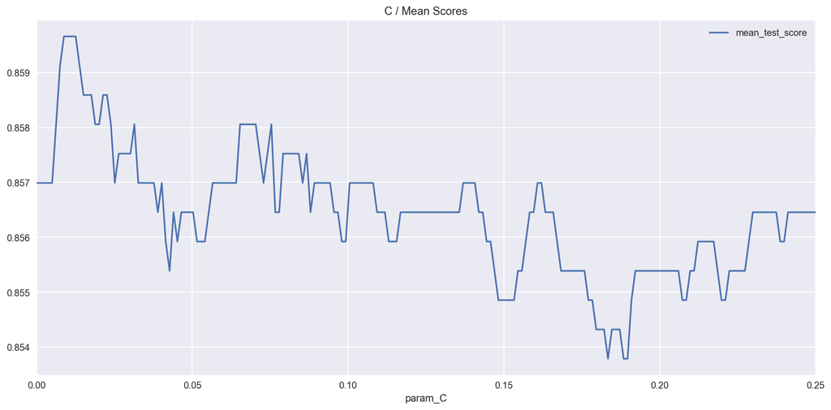

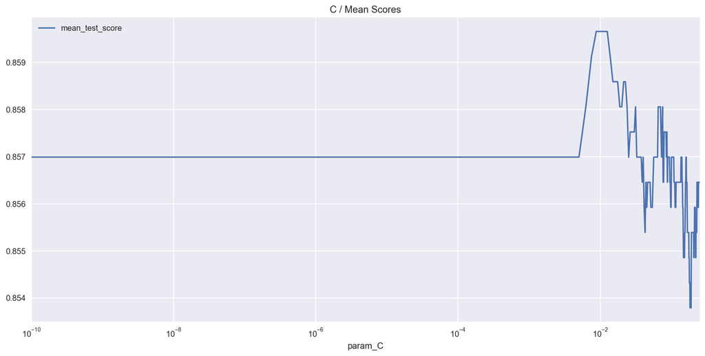

```python
print( "Best C was: ", results.best_params_)
df_score.plot(x="param_C", y="mean_test_score", title="C / Mean Scores")

#plt.xscale('log')

df_score.plot( x="param_C", y="mean_test_score", title="C / Mean Scores")
plt.xscale('log')
plt.show()
```

```
Training set score: 0.862
Test set score: 0.856
Training set score: 0.864
Test set score: 0.857
Training set score: 0.860
Test set score: 0.855
```

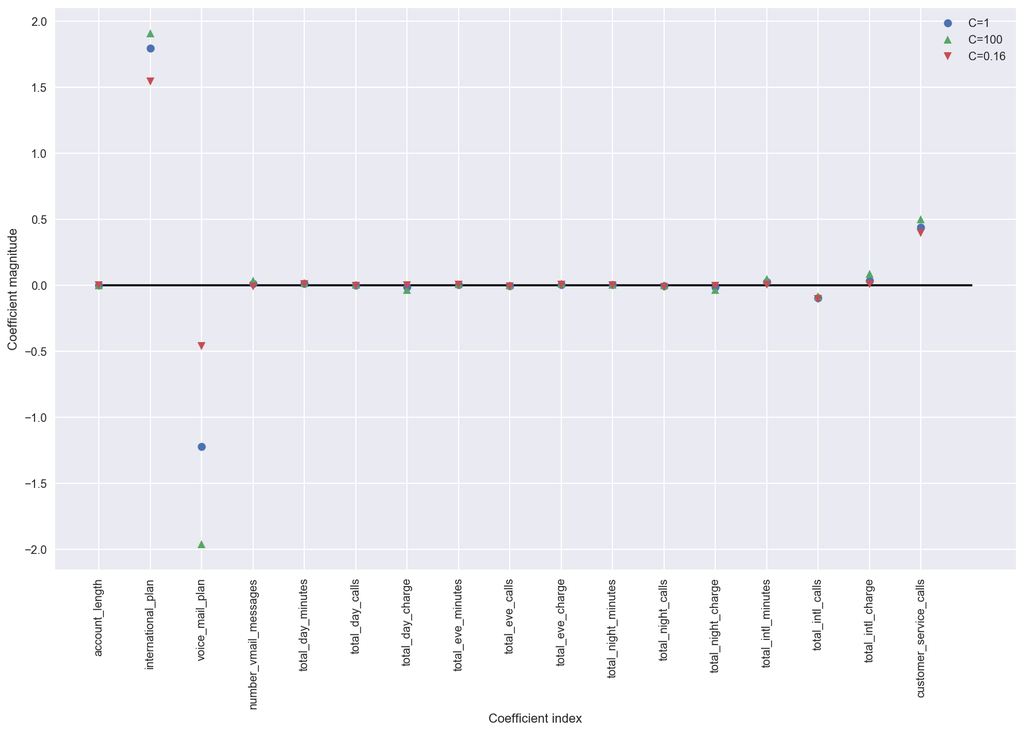

```python
#https://elvinouyang.github.io/study%20notes/python-linear-models-for-classification/
# Coefficient index
logreg = LogisticRegression().fit(X_train, y_train)
print("Training set score: {:.3f}".format(logreg.score(X_train, y_train)))
print("Test set score: {:.3f}".format(logreg.score(X_test, y_test)))

logreg100 = LogisticRegression(C=100).fit(X_train, y_train)

print("Training set score: {:.3f}".format(logreg100.score(X_train, y_train)))
print("Test set score: {:.3f}".format(logreg100.score(X_test, y_test)))


logreg016 = LogisticRegression(C=0.16708874371859295).fit(X_train, y_train)

print("Training set score: {:.3f}".format(logreg016.score(X_train, y_train)))
print("Test set score: {:.3f}".format(logreg016.score(X_test, y_test)))
plt.figure(figsize=(15,9))
plt.plot(logreg.coef_.T, 'o', label="C=1")
plt.plot(logreg100.coef_.T, '^', label="C=100")
plt.plot(logreg016.coef_.T, 'v', label="C=0.16")
plt.xticks(range(X_train.shape[1]), X_train.columns, rotation=90)
plt.hlines(0, 0, X_train.shape[1])
#plt.ylim(-1, 1)
plt.xlabel("Coefficient index")
plt.ylabel("Coefficient magnitude")
plt.legend()
```

## Construct some pipelines on GridsearchCV

```python
# https://www.kdnuggets.com/2018/01/managing-machine-learning-workflows-scikit-learn-pipelines-part-3.html
pipe_lr = Pipeline([('scl', StandardScaler()),
                    ('clf', LogisticRegression(random_state=42))])

pipe_lr_pca = Pipeline([('scl', StandardScaler()),
                        ('pca', PCA(n_components=2)),
                        ('clf', LogisticRegression(random_state=42))])

pipe_rf = Pipeline([('scl', StandardScaler()),
                    ('clf', RandomForestClassifier(random_state=42))])

pipe_rf_pca = Pipeline([('scl', StandardScaler()),
                        ('pca', PCA(n_components=2)),
                        ('clf', RandomForestClassifier(random_state=42))])

pipe_svm = Pipeline([('scl', StandardScaler()),
                     ('clf', SVC(random_state=42))])

pipe_svm_pca = Pipeline([('scl', StandardScaler()),
                         ('pca', PCA(n_components=2)),
                         ('clf', SVC(random_state=42))])

# Set grid search params
param_range = [1, 2, 3, 4, 5, 6, 7, 8, 9, 10]
param_range_fl = [1.0, 0.5, 0.1]

grid_params_lr = [{'clf__penalty': ['l1', 'l2'],
                   'clf__C': param_range_fl,
                   'clf__solver': ['liblinear']}]

grid_params_rf = [{'clf__criterion': ['gini', 'entropy'],
                   'clf__min_samples_leaf': param_range,
                   'clf__max_depth': param_range,
                   'clf__min_samples_split': param_range[1:]}]

grid_params_svm = [{'clf__kernel': ['linear', 'rbf'],
                    'clf__C': param_range}]

# Construct grid searches
jobs = -1

gs_lr = GridSearchCV(estimator=pipe_lr,
                     param_grid=grid_params_lr,
                     scoring='accuracy',
                     cv=10)

gs_lr_pca = GridSearchCV(estimator=pipe_lr_pca,
                         param_grid=grid_params_lr,
                         scoring='accuracy',
                         cv=10)

gs_rf = GridSearchCV(estimator=pipe_rf,
                     param_grid=grid_params_rf,
                     scoring='accuracy',
                     cv=10,
                     n_jobs=jobs)

gs_rf_pca = GridSearchCV(estimator=pipe_rf_pca,
                         param_grid=grid_params_rf,
                         scoring='accuracy',
                         cv=10,
                         n_jobs=jobs)

gs_svm = GridSearchCV(estimator=pipe_svm,
                      param_grid=grid_params_svm,
                      scoring='accuracy',
                      cv=10,
                      n_jobs=jobs)

gs_svm_pca = GridSearchCV(estimator=pipe_svm_pca,
                          param_grid=grid_params_svm,
                          scoring='accuracy',
                          cv=10,
                          n_jobs=jobs)

# List of pipelines for ease of iteration
grids = [gs_lr, gs_lr_pca, gs_rf, gs_rf_pca, gs_svm, gs_svm_pca]

# Dictionary of pipelines and classifier types for ease of reference
grid_dict = {0: 'Logistic Regression', 1: 'Logistic Regression w/PCA',
                2: 'Random Forest', 3: 'Random Forest w/PCA',
                4: 'Support Vector Machine', 5: 'Support Vector Machine w/PCA'}

# Fit the grid search objects
print('Performing model optimizations...')
best_acc = 0.0
best_clf = 0
best_gs = ''
for idx, gs in enumerate(grids):
    print('\nEstimator: %s' % grid_dict[idx])
    # Fit grid search
    gs.fit(X_train, y_train)
    # Best params
    print('Best params: %s' % gs.best_params_)
    # Best training data accuracy
    print('Best training accuracy: %.3f' % gs.best_score_)
    # Predict on test data with best params
    y_pred = gs.predict(X_test)
    # Test data accuracy of model with best params
    print('Test set accuracy score for best params: %.3f ' %
          accuracy_score(y_test, y_pred))
    # Track best (highest test accuracy) model
    if accuracy_score(y_test, y_pred) > best_acc:
        best_acc = accuracy_score(y_test, y_pred)
        best_gs = gs
        best_clf = idx
print('\nClassifier with best test set accuracy: %s' % grid_dict[best_clf])

# Save best grid search pipeline to file
#dump_file = 'best_gs_pipeline.pkl'
#joblib.dump(best_gs, dump_file, compress=1)
#print('\nSaved %s grid search pipeline to file: %s' % (grid_dict[best_clf], dump_file))
```

```
Performing model optimizations...

Estimator: Logistic Regression
Best params: {'clf__C': 1.0, 'clf__penalty': 'l2', 'clf__solver': 'liblinear'}
Best training accuracy: 0.863
Test set accuracy score for best params: 0.859

Estimator: Logistic Regression w/PCA
Best params: {'clf__C': 1.0, 'clf__penalty': 'l1', 'clf__solver': 'liblinear'}
Best training accuracy: 0.857
Test set accuracy score for best params: 0.845

Estimator: Random Forest
Best params: {'clf__criterion': 'gini', 'clf__max_depth': 10, 'clf__min_samples_leaf': 1, 'clf__min_samples_split': 3}
Best training accuracy: 0.946
Test set accuracy score for best params: 0.938

Estimator: Random Forest w/PCA
Best params: {'clf__criterion': 'entropy', 'clf__max_depth': 5, 'clf__min_samples_leaf': 3, 'clf__min_samples_split': 2}
Best training accuracy: 0.859
Test set accuracy score for best params: 0.845

Estimator: Support Vector Machine
Best params: {'clf__C': 3, 'clf__kernel': 'rbf'}
Best training accuracy: 0.919
Test set accuracy score for best params: 0.920

Estimator: Support Vector Machine w/PCA
Best params: {'clf__C': 1, 'clf__kernel': 'linear'}
Best training accuracy: 0.857
Test set accuracy score for best params: 0.845

Classifier with best test set accuracy: Random Forest
```

##### Learning:

Shown above, when using all the features, the Random Forest classifier has the best test set accuracy. This is a risk of overfitting.

## 3.Feature selections and engineering

### 1. Univariate Selection

```python
# feature extraction
test = SelectKBest(score_func=chi2, k=8)
fit = test.fit(X_test,y_test)
# summarize scores
np.set_printoptions(precision=3)
df = pd.DataFrame(index = X.columns,data=fit.scores_,columns=['Score'])
print(df.sort_values(['Score'], ascending=False))
features = fit.transform(X)
# summarize selected features
print(features[0:5,:])
#features.head()
```

```
                             Score
total_day_minutes       459.045198
number_vmail_messages    87.011880
total_day_charge         78.037138
international_plan       60.708018
customer_service_calls   53.602355
total_eve_minutes        39.603624
account_length           13.618878
total_night_minutes      13.308143
total_intl_calls          7.631670
voice_mail_plan           5.275633
total_intl_minutes        3.733468
total_eve_charge          3.364022
total_day_calls           2.976705
total_intl_charge         1.004046
total_night_charge        0.597837
total_eve_calls           0.571342
total_night_calls         0.137715
[[ 128.      0.     25.    265.1    45.07  197.4   244.7     1.  ]
 [ 107.      0.     26.    161.6    27.47  195.5   254.4     1.  ]
 [ 137.      0.      0.    243.4    41.38  121.2   162.6     0.  ]
 [  84.      1.      0.    299.4    50.9    61.9   196.9     2.  ]
 [  75.      1.      0.    166.7    28.34  148.3   186.9     3.  ]]
```

### 2. Recursive Feature Elimination

### 3. Feature Importance - ExtraTreesClassifier

### 4. RM

### 5. stability selection, RFE and everything side by side

```python
#http://blog.datadive.net/selecting-good-features-part-iv-stability-selection-rfe-and-everything-side-by-side/

names = X_train.columns.tolist()

ranks = {}

def rank_to_dict(ranks, names, order=1):
    minmax = MinMaxScaler()
    ranks = minmax.fit_transform(order*np.array([ranks]).T).T[0]
    ranks = map(lambda x: round(x, 2), ranks)
    return dict(zip(names, ranks ))

lr = LinearRegression(normalize=True)
lr.fit(X_train, y_train)
ranks["Linear reg"] = rank_to_dict(np.abs(lr.coef_), names)

ridge = Ridge(alpha=7)
ridge.fit(X_train, y_train)
ranks["Ridge"] = rank_to_dict(np.abs(ridge.coef_), names)


lasso = Lasso(alpha=.05)
lasso.fit(X_train, y_train)
ranks["Lasso"] = rank_to_dict(np.abs(lasso.coef_), names)


rlasso = RandomizedLasso(alpha=0.04)
rlasso.fit(X_train, y_train)
ranks["Stability"] = rank_to_dict(np.abs(rlasso.scores_), names)

#stop the search when 5 features are left (they will get equal scores)
rfe = RFE(lr, n_features_to_select=5)
rfe.fit(X_train,y_train)
ranks["RFE"] = rank_to_dict(rfe.ranking_, names, order=-1)

rf = RandomForestRegressor()
rf.fit(X_train,y_train)
ranks["RF"] = rank_to_dict(rf.feature_importances_, names)


f, pval  = f_regression(X_train, y_train, center=True)
ranks["Corr."] = rank_to_dict(f, names)

mine = MINE()
mic_scores = []
for i in range(X_train.shape[1]):
    mine.compute_score(X_train.iloc[:,i], y_train)
    m = mine.mic()
    mic_scores.append(m)

ranks["MIC"] = rank_to_dict(mic_scores, names)


r = {}
for name in names:
    r[name] = round(np.mean([ranks[method][name] for method in ranks.keys()]), 2)

methods = sorted(ranks.keys())
ranks["Mean"] = r
methods.append("Mean")

#print ("\t%s" % "\t".join(methods))
#for name in names:
#    print ("%s%s\t%s" % ("|",name, "|\t|".join(map(str,
#                         [ranks[method][name] for method in methods]))))
final_f_table = pd.DataFrame.from_dict(ranks)
t=final_f_table.sort_values(by='Mean', ascending=False).iloc[0:8,:]
short_features = t.index.tolist()
short_features
t
```

|  | Corr. | Lasso | Linear reg | MIC | Mean | RF | RFE | Ridge | Stability |
| --- | --- | --- | --- | --- | --- | --- | --- | --- | --- |
| total_day_charge | 0.65 | 0.00 | 0.85 | 1.00 | 0.54 | 0.82 | 1.00 | 0.01 | 0.0 |
| total_day_minutes | 0.65 | 0.06 | 0.15 | 1.00 | 0.48 | 1.00 | 1.00 | 0.01 | 0.0 |
| international_plan | 1.00 | 0.00 | 0.15 | 0.17 | 0.45 | 0.29 | 1.00 | 1.00 | 0.0 |
| customer_service_calls | 0.61 | 1.00 | 0.03 | 0.24 | 0.41 | 0.56 | 0.67 | 0.20 | 0.0 |
| total_intl_charge | 0.05 | 0.00 | 1.00 | 0.30 | 0.31 | 0.13 | 1.00 | 0.02 | 0.0 |
| total_eve_charge | 0.17 | 0.00 | 0.34 | 0.52 | 0.28 | 0.25 | 0.92 | 0.01 | 0.0 |
| total_eve_minutes | 0.17 | 0.03 | 0.03 | 0.53 | 0.27 | 0.55 | 0.83 | 0.00 | 0.0 |
| total_intl_minutes | 0.05 | 0.06 | 0.27 | 0.30 | 0.25 | 0.32 | 1.00 | 0.02 | 0.0 |

#### Learning: Features selection

I am going to use the 8 features that have the highest mean for the final modelings.

## 4.Implementing the model with final selection of features

```python
X_train, X_test, y_train, y_test = train_test_split(short_X, y, test_size=0.25, random_state=42)
clfs = []
print('10-fold cross validation:')
print('-'*85)
for clf, label in zip([LR, RF, SVM, KNC, DTC, ABC, BC, GBC],
                      ['Logistic Regression',
                       'Random Forest',
                       'Support Vector Machine',
                       'KNeighbors',
                       'Decision Tree',
                       'Ada Boost',
                       'Bagging',
                       'Gradient Boosting']):

    for scoring in ['roc_auc', 'accuracy', 'recall', 'precision']:
        scores = cross_val_score(clf, X_train, y_train, scoring=scoring, cv=10)
        print(scoring.upper(), ':')
        print('{}: Train CV average {} is {:0.2f}, '.format(label.upper(), scoring,scores.mean()))
        md = clf.fit(X_train, y_train)
        clfs.append(md)
        print("Test Accuracy: %0.2f " % (metrics.accuracy_score(clf.predict(X_test), y_test)))
        print('-'*85)
```

```
10-fold cross validation:
-------------------------------------------------------------------------------------
ROC_AUC :
LOGISTIC REGRESSION: Train CV average roc_auc is 0.81,
Test Accuracy: 0.77
-------------------------------------------------------------------------------------
ACCURACY :
LOGISTIC REGRESSION: Train CV average accuracy is 0.76,
Test Accuracy: 0.77
-------------------------------------------------------------------------------------
RECALL :
LOGISTIC REGRESSION: Train CV average recall is 0.75,
Test Accuracy: 0.77
-------------------------------------------------------------------------------------
PRECISION :
LOGISTIC REGRESSION: Train CV average precision is 0.35,
Test Accuracy: 0.77
-------------------------------------------------------------------------------------
ROC_AUC :
RANDOM FOREST: Train CV average roc_auc is 0.89,
Test Accuracy: 0.92
-------------------------------------------------------------------------------------
ACCURACY :
RANDOM FOREST: Train CV average accuracy is 0.92,
Test Accuracy: 0.92
-------------------------------------------------------------------------------------
RECALL :
RANDOM FOREST: Train CV average recall is 0.56,
Test Accuracy: 0.92
-------------------------------------------------------------------------------------
PRECISION :
RANDOM FOREST: Train CV average precision is 0.81,
Test Accuracy: 0.92
-------------------------------------------------------------------------------------
ROC_AUC :
SUPPORT VECTOR MACHINE: Train CV average roc_auc is 0.88,
Test Accuracy: 0.86
-------------------------------------------------------------------------------------
ACCURACY :
SUPPORT VECTOR MACHINE: Train CV average accuracy is 0.87,
```

[output cut: 75 more lines]

```
GRADIENT BOOSTING: Train CV average roc_auc is 0.89,
Test Accuracy: 0.91
-------------------------------------------------------------------------------------
ACCURACY :
GRADIENT BOOSTING: Train CV average accuracy is 0.92,
Test Accuracy: 0.91
-------------------------------------------------------------------------------------
RECALL :
GRADIENT BOOSTING: Train CV average recall is 0.58,
Test Accuracy: 0.91
-------------------------------------------------------------------------------------
PRECISION :
GRADIENT BOOSTING: Train CV average precision is 0.82,
Test Accuracy: 0.91
-------------------------------------------------------------------------------------
```

#### Learning:

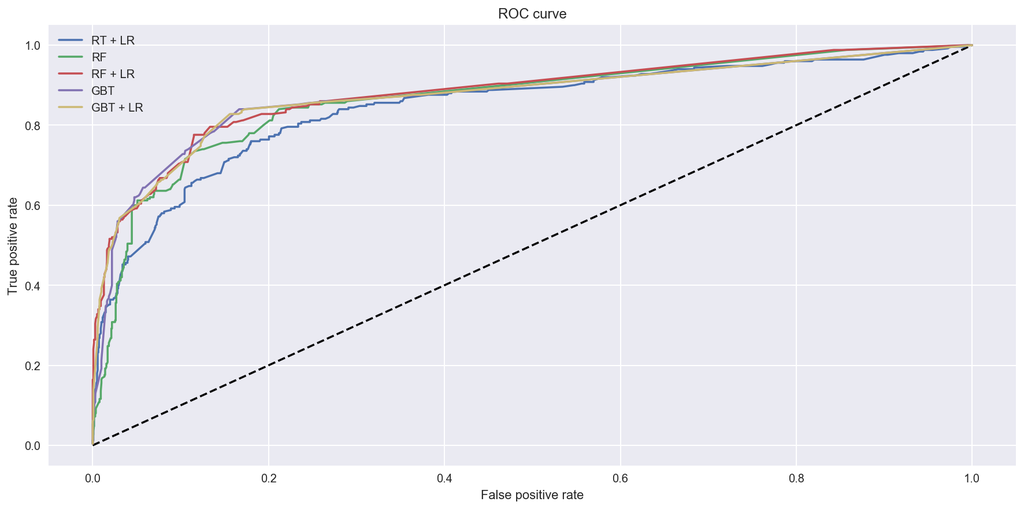

```python
# Author: Tim Head <betatim@gmail.com>
# http://scikit-learn.org/stable/auto_examples/ensemble/plot_feature_transformation.html
# #sphx-glr-auto-examples-ensemble-plot-feature-transformation-py
# License: BSD 3 clause


n_estimator = 10
X, y = short_X, y
X_train, X_test, y_train, y_test = train_test_split(X, y, test_size=0.5)
# It is important to train the ensemble of trees on a different subset
# of the training data than the linear regression model to avoid
# overfitting, in particular if the total number of leaves is
# similar to the number of training samples
X_train, X_train_lr, y_train, y_train_lr = train_test_split(X_train,
                                                            y_train,
                                                            test_size=0.5)


# Unsupervised transformation based on totally random trees
rt = RandomTreesEmbedding(max_depth=3, n_estimators=n_estimator,
    random_state=42)

rt_lm = LogisticRegression()
pipeline = make_pipeline(rt, rt_lm)
pipeline.fit(X_train, y_train)
y_pred_rt = pipeline.predict_proba(X_test)[:, 1]
fpr_rt_lm, tpr_rt_lm, _ = roc_curve(y_test, y_pred_rt)

# Supervised transformation based on random forests
rf = RandomForestClassifier(max_depth=3, n_estimators=n_estimator)
rf_enc = OneHotEncoder()
rf_lm = LogisticRegression()
rf.fit(X_train, y_train)
rf_enc.fit(rf.apply(X_train))
rf_lm.fit(rf_enc.transform(rf.apply(X_train_lr)), y_train_lr)

y_pred_rf_lm = rf_lm.predict_proba(rf_enc.transform(rf.apply(X_test)))[:, 1]
fpr_rf_lm, tpr_rf_lm, _ = roc_curve(y_test, y_pred_rf_lm)

grd = GradientBoostingClassifier(n_estimators=n_estimator)
grd_enc = OneHotEncoder()
grd_lm = LogisticRegression()
grd.fit(X_train, y_train)
grd_enc.fit(grd.apply(X_train)[:, :, 0])
grd_lm.fit(grd_enc.transform(grd.apply(X_train_lr)[:, :, 0]), y_train_lr)

y_pred_grd_lm = grd_lm.predict_proba(
    grd_enc.transform(grd.apply(X_test)[:, :, 0]))[:, 1]
fpr_grd_lm, tpr_grd_lm, _ = roc_curve(y_test, y_pred_grd_lm)


# The gradient boosted model by itself
y_pred_grd = grd.predict_proba(X_test)[:, 1]
fpr_grd, tpr_grd, _ = roc_curve(y_test, y_pred_grd)


# The random forest model by itself
y_pred_rf = rf.predict_proba(X_test)[:, 1]
fpr_rf, tpr_rf, _ = roc_curve(y_test, y_pred_rf)

plt.figure(1)
plt.plot([0, 1], [0, 1], 'k--')
plt.plot(fpr_rt_lm, tpr_rt_lm, label='RT + LR')
plt.plot(fpr_rf, tpr_rf, label='RF')
plt.plot(fpr_rf_lm, tpr_rf_lm, label='RF + LR')
plt.plot(fpr_grd, tpr_grd, label='GBT')
plt.plot(fpr_grd_lm, tpr_grd_lm, label='GBT + LR')
plt.xlabel('False positive rate')
plt.ylabel('True positive rate')
plt.title('ROC curve')
plt.legend(loc='best')
plt.show()
```

#### Learning:

The graph above shows that with near half the amount of features,the turning point for ROC has dropped but is still above 0.75 which is still accurate.

### PIPELINE AND GRIDSEARCHCV

https://www.civisanalytics.com/blog/workflows-in-python-using-pipeline-and-gridsearchcv-for-more-compact-and-comprehensive-code/

```python
for i in range(1,7):
    select = SelectKBest(k=i)
    clf = RandomForestClassifier()

    steps = [('feature_selection', select),
            ('random_forest', clf)]

    pipeline = Pipeline(steps)

    ### fit your pipeline on X_train and y_train
    pipeline.fit( X_train, y_train )
    ### call pipeline.predict() on your X_test data to make a set of test predictions
    y_prediction = pipeline.predict( X_test )
    ### test your predictions using sklearn.classification_report()
    report = classification_report( y_test, y_prediction )
    ### and print the report
    print(report)
```

```
             precision    recall  f1-score   support

          0       0.87      0.91      0.89      1417
          1       0.28      0.20      0.23       250

avg / total       0.78      0.80      0.79      1667

             precision    recall  f1-score   support

          0       0.86      0.91      0.88      1417
          1       0.27      0.20      0.23       250

avg / total       0.78      0.80      0.79      1667

             precision    recall  f1-score   support

          0       0.87      0.93      0.90      1417
          1       0.31      0.19      0.24       250

avg / total       0.78      0.82      0.80      1667

             precision    recall  f1-score   support

          0       0.87      0.96      0.92      1417
          1       0.50      0.22      0.30       250

avg / total       0.82      0.85      0.82      1667

             precision    recall  f1-score   support

          0       0.88      0.97      0.92      1417
          1       0.55      0.24      0.33       250

avg / total       0.83      0.86      0.83      1667

             precision    recall  f1-score   support

          0       0.91      0.96      0.94      1417
          1       0.69      0.48      0.56       250

avg / total       0.88      0.89      0.88      1667
```

```python
# Fit the grid search objects
print('Performing model optimizations...')
best_acc = 0.0
best_clf = 0
best_gs = ''
for idx, gs in enumerate(grids):
    print('\nEstimator: %s' % grid_dict[idx])
    # Fit grid search
    gs.fit(X_train, y_train)
    # Best params
    print('Best params: %s' % gs.best_params_)
    # Best training data accuracy
    print('Best training accuracy: %.3f' % gs.best_score_)
    # Predict on test data with best params
    y_pred = gs.predict(X_test)
    # Test data accuracy of model with best params
    print('Test set accuracy score for best params: %.3f ' %
          accuracy_score(y_test, y_pred))
    # Track best (highest test accuracy) model
    if accuracy_score(y_test, y_pred) > best_acc:
        best_acc = accuracy_score(y_test, y_pred)
        best_gs = gs
        best_clf = idx
        print('\nClassifier with best test set accuracy: %s' % grid_dict[best_clf])

print('\nClassifier with best test set accuracy: %s' % grid_dict[best_clf])

# Save best grid search pipeline to file
#dump_file = 'best_gs_pipeline.pkl'
#joblib.dump(best_gs, dump_file, compress=1)
#print('\nSaved %s grid search pipeline to file: %s' % (grid_dict[best_clf], dump_file))
```

```
Performing model optimizations...

Estimator: Logistic Regression
Best params: {'clf__C': 0.1, 'clf__penalty': 'l1', 'clf__solver': 'liblinear'}
Best training accuracy: 0.870
Test set accuracy score for best params: 0.857

Classifier with best test set accuracy: Logistic Regression

Estimator: Logistic Regression w/PCA
Best params: {'clf__C': 1.0, 'clf__penalty': 'l1', 'clf__solver': 'liblinear'}
Best training accuracy: 0.874
Test set accuracy score for best params: 0.857

Estimator: Random Forest
Best params: {'clf__criterion': 'gini', 'clf__max_depth': 9, 'clf__min_samples_leaf': 1, 'clf__min_samples_split': 2}
Best training accuracy: 0.927
Test set accuracy score for best params: 0.903

Classifier with best test set accuracy: Random Forest

Estimator: Random Forest w/PCA
Best params: {'clf__criterion': 'entropy', 'clf__max_depth': 7, 'clf__min_samples_leaf': 8, 'clf__min_samples_split': 2}
Best training accuracy: 0.897
Test set accuracy score for best params: 0.866

Estimator: Support Vector Machine
Best params: {'clf__C': 2, 'clf__kernel': 'rbf'}
Best training accuracy: 0.900
Test set accuracy score for best params: 0.893

Estimator: Support Vector Machine w/PCA
Best params: {'clf__C': 1, 'clf__kernel': 'rbf'}
Best training accuracy: 0.891
Test set accuracy score for best params: 0.867

Classifier with best test set accuracy: Random Forest
```

##### Learning: Results from grid search objects

For the above model, I have used a mixture of methods to deal with the imbalanced data. After the optimization, the Random Forest gave the highest prediction accuracy. However, the best model has max depth of 9 and in general the best recommended max depth is 5. Therefore, I think we should consider the second best option of SVM.

With half of the original features, the model has managed to predict at a slightly lower level accuracy compared to the model with the full features. This should reduce the risk of over fitting.

# Conclusion:

- It is important to continue testing the model with the latest available data and monitor the accuracy changes.
- In the real world example, we would use this result from the models to help us design the products that meet our customer needs.
- Study further around imbalance dataset to make sure the approach used is correct.
- Study further around recall, precision etc to ensure I can interpret the data correctly.